# Take-home Assignment #1

Jakob Berg and Sophia Grill

2020-07-06

# 1. Acquire the dataset by running the following chunk. Install the missing packages first if necessary.

```r
library(rvest)
library(tidyverse)
url <- "https://www.nu3.de/blogs/nutrition/food-carbon-footprint-index-2018" # url to scrape

# scrape the website
url_html <- read_html(url) # read the page

# extract the HTML table
whole_table <- url_html %>%
  html_nodes('table') %>% # select table
  html_table(fill = TRUE) %>% # parse it to date frame
  .[[1]] # pull out the data frame

table_content <- whole_table %>%
  select(-X1) %>% # remove redundant column
  filter(!dplyr::row_number() %in% 1:3) # remove redundant rows

raw_headers <- url_html %>%
  html_nodes(".thead-icon") %>% # select element
  html_attr('title') # pull out column names

tidy_bottom_header <- raw_headers[28:length(raw_headers)]

raw_middle_header <- raw_headers[17:27]

tidy_headers <- c( # fix headers
  rep(raw_middle_header[1:7], each = 2),
  "animal_total",
  rep(raw_middle_header[8:length(raw_middle_header)], each = 2),
  "non_animal_total",
  "country_total")

combined_colnames <- paste(tidy_headers, tidy_bottom_header, sep = ';') # create column names
colnames(table_content) <- c("Country", combined_colnames) # add column names
table_content_tbl <- as_tibble(table_content)
table_content_tbl
```

```
## # A tibble: 130 x 26
##    Country `Pork;Supplied ~ `Pork;Kg CO2/pe~ `Poultry;Suppli~ `Poultry;Kg CO2~
##    <chr>   <chr>            <chr>            <chr>            <chr>
##  1 Argent~ 10.51            37.20            38.66            41.53
##  2 Austra~ 24.14            85.44            46.12            49.54
##  3 Albania 10.88            38.51            13.23            14.21
##  4 Iceland 21.69            76.77            26.87            28.86
##  5 New Ze~ 22.29            78.90            34.98            37.58
##  6 USA     27.64            97.83            50.01            53.72
##  7 Uruguay 16.84            59.61            27.45            29.49
##  8 Luxemb~ 43.58            154.25           21.37            22.96
##  9 Brazil  12.60            44.60            45.00            48.34
## 10 Kazakh~ 10.36            36.67            18.38            19.74
## # ... with 120 more rows, and 21 more variables: `Beef;Supplied for Consumption
## #   (kg/person/year)` <chr>, `Beef;Kg CO2/person/year` <chr>, `Lamb &
## #   Goat;Supplied for Consumption (kg/person/year)` <chr>, `Lamb & Goat;Kg
## #   CO2/person/year` <chr>, `Fish;Supplied for Consumption
## #   (kg/person/year)` <chr>, `Fish;Kg CO2/person/year` <chr>, `Eggs;Supplied
## #   for Consumption (kg/person/year)` <chr>, `Eggs;Kg CO2/person/year` <chr>,
## #   `Milk - inc. cheese;Supplied for Consumption (kg/person/year)` <chr>, `Milk
## #   - inc. cheese;Kg CO2/person/year` <chr>, `animal_total;Kg
## #   CO2/person/year` <chr>, `Wheat and Wheat Products;Supplied for Consumption
## #   (kg/person/year)` <chr>, `Wheat and Wheat Products;Kg
## #   CO2/person/year` <chr>, `Rice;Supplied for Consumption
## #   (kg/person/year)` <chr>, `Rice;Kg CO2/person/year` <chr>,
## #   `Soybeans;Supplied for Consumption (kg/person/year)` <chr>, `Soybeans;Kg
## #   CO2/person/year` <chr>, `Nuts inc. Peanut Butter;Supplied for Consumption
## #   (kg/person/year)` <chr>, `Nuts inc. Peanut Butter;Kg
## #   CO2/person/year` <chr>, `non_animal_total;Kg CO2/person/year` <chr>,
## #   `country_total;Kg CO2/person/year` <chr>
```

# 2. Make the dataset tidy. Ask yourself the following questions: which variables does it contain? How can I put them into separate rows?

# 3. Change the column names so that they do not have to be surrounded by backticks (i.e., they should only consist of lowercase characters, numbers, dots, and underscores).

```r
long_table <- table_content %>%
 pivot_longer(cols = -Country, names_to = "Category", values_to = "Values") %>% # column names of category variable
 separate(col = Category, into = c("Food Category", "Metric"), sep = ';') # separates food category from metric variables

tidy_table <- long_table %>%
   pivot_wider(names_from = Metric, values_from = Values) # splits metric variables into consumption and emmission


final_table <- tidy_table %>%
 rename(consumption = `Supplied for Consumption (kg/person/year)`,
        co2_emmission = `Kg CO2/person/year`,
        country = Country,
        food_category = `Food Category`) %>%
 drop_na() # drops all NAs, important because we want to get rid of the emmission sum entries of each country

head(final_table, 40)
```

```
## # A tibble: 40 x 4
##    country   food_category            consumption co2_emmission
##    <chr>     <chr>                    <chr>       <chr>
##  1 Argentina Pork                     10.51       37.20
##  2 Argentina Poultry                  38.66       41.53
##  3 Argentina Beef                     55.48       1712.00
##  4 Argentina Lamb & Goat              1.56        54.63
##  5 Argentina Fish                     4.36        6.96
##  6 Argentina Eggs                     11.39       10.46
##  7 Argentina Milk - inc. cheese       195.08      277.87
##  8 Argentina Wheat and Wheat Products 103.11      19.66
##  9 Argentina Rice                     8.77        11.22
## 10 Argentina Soybeans                 0.00        0.00
## # ... with 30 more rows
```

# 4. Coerce variables to factors (if it makes sense).

We coerced the countries into factors, because in the original table on the website they were arranged due to co2 emmissions (descending). Also, we had to coerce consumption and co2_emmission to numeric variables in order to use them in our plots.

```r
final_table <- mutate_at(final_table, vars(country, food_category), as.factor)
final_table <- mutate_at(final_table, vars(consumption, co2_emmission), as.numeric)

head(final_table)
```

```
## # A tibble: 6 x 4
##   country   food_category consumption co2_emmission
##   <fct>     <fct>               <dbl>         <dbl>
## 1 Argentina Pork                10.5          37.2
## 2 Argentina Poultry             38.7          41.5
## 3 Argentina Beef                55.5        1712
## 4 Argentina Lamb & Goat          1.56         54.6
## 5 Argentina Fish                 4.36          6.96
## 6 Argentina Eggs                11.4          10.5
```

# 5. Visualize your dataset with `ggplot2`.

## a. A scatter plot with `consumption` on the x and `kg_co2` on the y axis. Color the dots according to `country`.

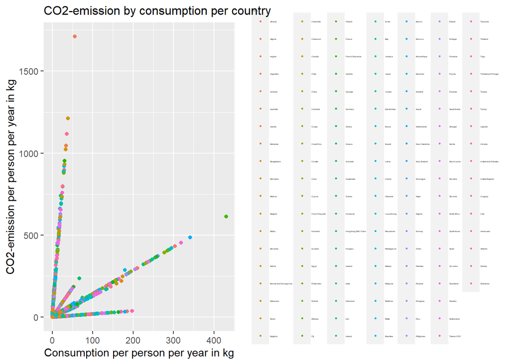

```r
ggplot(data = final_table) +
  geom_point(aes(x = consumption, y = co2_emmission, color = country)) +
  theme(legend.position = "right", # determines position of legend in plot
        legend.title = element_text(size = 2),
        legend.text = element_text(size = 2),
        plot.title = element_text(size = 12)) +
  guides(color = guide_legend(override.aes = list(size = 0.5)), # determines size of legend
         fill = guide_legend(nrow = 5, byrow = TRUE)) +
  ggtitle("CO2-emission by consumption per country") +
  ylab("CO2-emission per person per year in kg") +
  xlab("Consumption per person per year in kg")
```

As you can see, there are a lot of different countries as colored data points. That is why we decided to group the countries into continents. Therefore, we used the countrycode package. But as we are workung with a tibble, we had to first convert it to a dataframe to make it work.

```r
final_table_df <- as.data.frame(final_table) # converts tibble to data frame


library(countrycode)
final_table_df$continent <- countrycode(sourcevar = final_table_df[, "country"],
                            origin = "country.name",
                            destination = "continent") # using the country code package to group countries into continents

head(final_table_df)
```

```
##     country food_category consumption co2_emmission continent
## 1 Argentina          Pork       10.51         37.20  Americas
## 2 Argentina       Poultry       38.66         41.53  Americas
## 3 Argentina          Beef       55.48       1712.00  Americas
## 4 Argentina   Lamb & Goat        1.56         54.63  Americas
## 5 Argentina          Fish        4.36          6.96  Americas
## 6 Argentina          Eggs       11.39         10.46  Americas
```

Now the colored dots in the graph represent different continents!

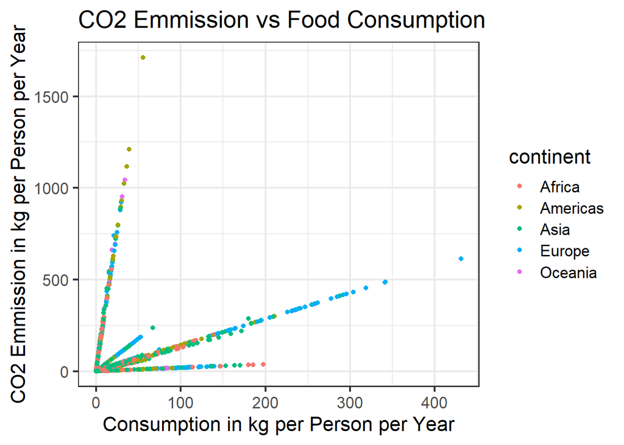

```r
ggplot(data = final_table_df) +
  geom_point(aes(x = consumption, y = co2_emmission, color = continent)) + # calling geom_point for a scatterplot
      labs(x = "Consumption in kg per Person per Year", y = "CO2 Emmission in kg per Person per Year",
       title = "CO2 Emmission vs Food Consumption")+
  theme_bw(base_size = 16) # choosing theme and font size
```

## b. A smoothed line with the same variables (no country-specific color coding though).

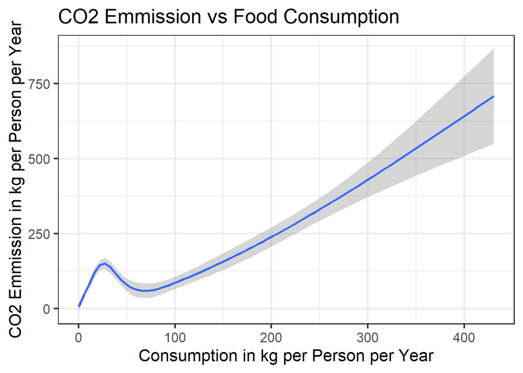

```r
ggplot(data = final_table) +
  geom_smooth(aes(x = consumption, y = co2_emmission)) +
      labs(x = "Consumption in kg per Person per Year", y = "CO2 Emmission in kg per Person per Year",
       title = "CO2 Emmission vs Food Consumption") +
  theme_bw(base_size = 16)
```

## c. Faceted graphs according to type of food.

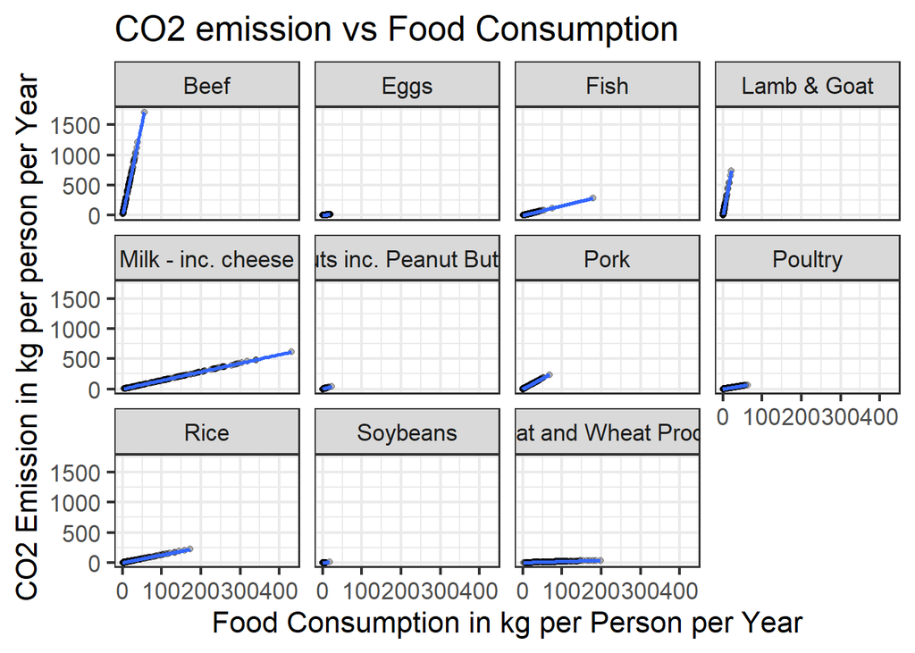

```r
final_table %>%
ggplot(aes (x = consumption, y = co2_emmission)) +
  geom_point(alpha = 0.3) + # sets size of points
    labs(x = "Food Consumption in kg per Person per Year", y = "CO2 Emission in kg per person per Year",
       title = "CO2 emission vs Food Consumption") +
  scale_y_continuous() +
  scale_x_continuous() +
  geom_smooth(method = lm,se = FALSE) +
  facet_wrap(~food_category, ncol = 4) + # creates 4 columns
  theme_bw(base_size = 16)
```

## d. A scatter plot with the sum of supply for consumption per country (x axis) and total CO2 emissions per country (y axis). Color the dots as in (a).

```r
consumption_sum <- final_table %>%
  group_by(country) %>%
  summarize(consumption_sum = sum(as.numeric(consumption), na.rm = FALSE)) # creates tibble with summed-up consumption per country
co2_sum <- final_table %>%
  group_by(country) %>%
  summarize(co2_sum = sum(as.numeric(co2_emmission), na.rm = FALSE)) # creates tibble with summed-up co2-emmission per country
```

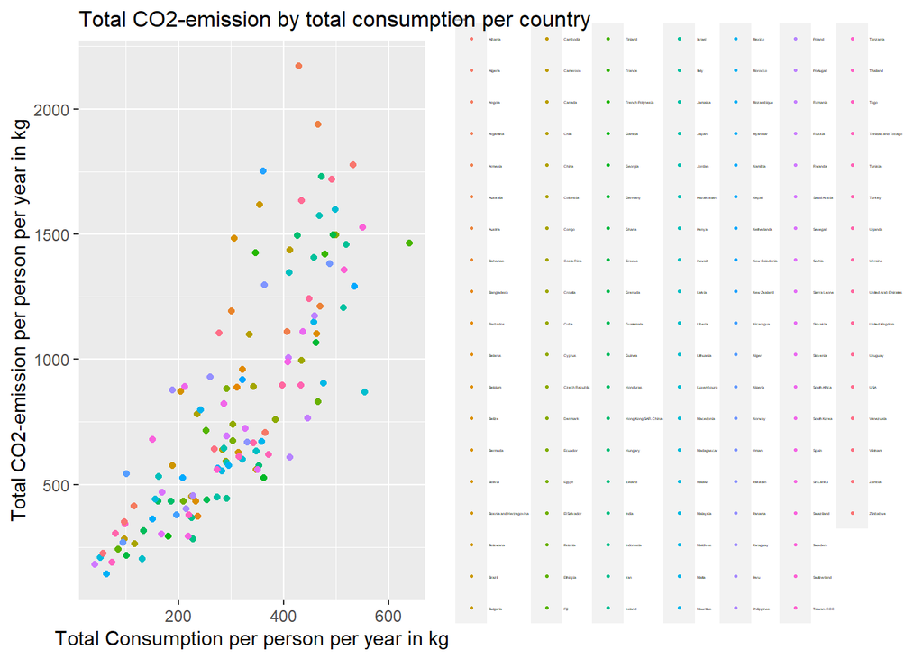

```r
sum_both <- merge(x = consumption_sum, y = co2_sum, by = "country", all = TRUE) # merges both tibbles created above


scatterplot_sum_both <- ggplot(data = sum_both) +
  geom_point(aes(x = consumption_sum, y = co2_sum, color = country)) +
  theme(legend.position = "right",
        legend.title = element_text(size = 2),
        legend.text = element_text(size = 2),
        plot.title = element_text(size = 12)) +
  guides(color = guide_legend(override.aes = list(size = 0.5)),
         fill = guide_legend(nrow = 5, byrow = TRUE)) +
  ggtitle("Total CO2-emission by total consumption per country") +
  ylab("Total CO2-emission per person per year in kg") +
  xlab("Total Consumption per person per year in kg")


scatterplot_sum_both
```

## e. Faceted graphs: countries that start with “a”–“l” and “m”–“z”.

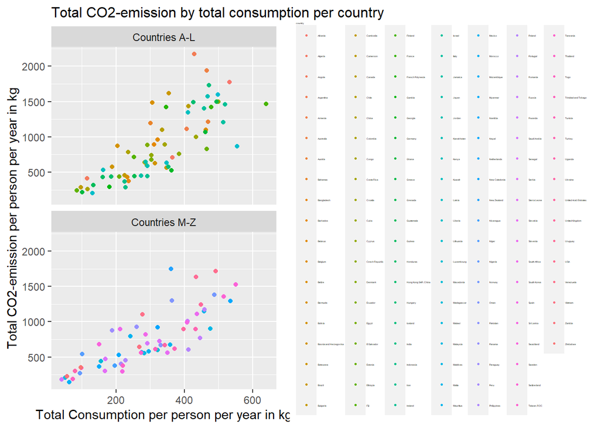

```r
sum_both_numbers <- sum_both %>%
  mutate(c_number = 1:130) %>%
  mutate(indicator = case_when(as.numeric(c_number) < 70 ~ 0,
                               as.numeric(c_number) >= 70 ~ 1)) # creates column with index about first letter of country


scatterplot_al_mz <- ggplot(sum_both_numbers) +
  geom_point(aes(consumption_sum, y = co2_sum, color = country)) +
  theme(legend.position = "right",
        legend.title = element_text(size = 2),
        legend.text = element_text(size = 2),
        plot.title = element_text(size = 12)) +
  guides(color = guide_legend(override.aes = list(size = 0.5)),
         fill = guide_legend(nrow = 5, byrow = TRUE)) +
  ylab("Total CO2-emission per person per year in kg") +
  xlab("Total Consumption per person per year in kg") +
  ggtitle("Total CO2-emission by total consumption per country") +
  facet_wrap(~indicator,
             labeller = labeller(indicator = # dtermines labels of facet wraps
    c("0" = "Countries A-L",
      "1" = "Countries M-Z")),
             nrow = 4)

scatterplot_al_mz
```

# 6. Store your dataset as a csv-file.

```r
write.csv(final_table, "final_table.csv")
```